**CSE2215** - Computer Graphics

Elmar Eisemann, Martin Skrodzki, Michael Weinmann, Ricardo Marroqium

# Ray Tracing

Here you will focus on the computation on ray intersection tests which is the most fundamental functionality of a ray tracer as well as other collision detection scenarios. We will also provide descriptions that help you in drawing rays and triangle meshes so that you can visually debug your results. Similar to the frameworks before, we provide the information where you have to implement the respective functionality.

### Rules

For this assignment the following rules apply:

**General**

- We strongly recommend to do the assignment **individually**.
- This practical will help you prepare for the programming exam.
- We ask you to give the practical a try yourself to see whether you can solve it. Remember that the programming exam will also be an individual assessment.
- As always, you can approach the TAs with questions during the lab sessions.
- Your should compile your code **on Windows with Visual Studio 2022** (using the default MSVC toolchain). Otherwise, the TAs might not be able to help you with related issues.
- Submission on Brightspace is not required for this practical.

**Evaluation**

- This practical is ungraded.
- We provide you with a unit test framework using the [Catch2](https://github.com/catchorg/Catch2/) under `tests` for you to self-test your solutions.
- To use the test framework, select and build the target `Bachelor_Practical4_Tests`
- You may add your own tests in ‘tests/your_tests.cpp’ and run them via the target `Bachelor_Practical4_YourTests`
- If it prints “xxx failed”, it means some of your solutions are incorrect. See the error messages in the console for a detailed explanation.
- If it prints “All tests passed”, you are good to go!

### Ray

A ray is defined by its origin, a direction and a parameter *t* indicating the intersection point. In the code it is defined as follows:

```cpp
struct Ray {
    glm::vec3 origin { 0.0f };
    glm::vec3 direction { 0.0f, 0.0f, -1.0f };
    float t { std::numeric_limits<float>::max() };
};
```

The intersection point of the ray is then defined as `p = ray.origin + ray.direction * ray.t`.

For every intersection method, the ray is passed by reference. You should check for intersections and update the `ray.t` value when necessary. Note that `ray.t` should always store the closest intersection parameter found so far, taking into consideration that rays should not intersect points behind the origin (only positive values for t).

In short:

1. no intersection is found or $t\leq 0$: **return false**
2. found intersection point **p**
   1. if **p** is closer to the ray origin then current intersection point: **return true** and **update ray.t**
   2. else **return false**

## Intersections

You have seen the three types of intersection in the lectures. We strongly recommend you to follow the methods described in the lectures. Below are more details on each type of intersection.

You are **not** supposed to use any functions from the following header file: https://glm.g-truc.net/0.9.0/api/a00162.html .

### Intersection tests for collision detection

In this first part of the assignment, we want to demonstrate the potential of intersection tests for scene analysis.

For this purpose, we consider a collision detection scenario that is often encountered in scene analysis for autonomous vehicles, traffic scenarios, or the interaction between robots. In this task, however, we consider collision detection for analyzing whether Pac-Man will be caught by 2 ghosts for a given motion in a particularly specified scenario depicted in the figure below.

[figure not shown]

For this task, we assume that both Pac-Man and the ghosts have a constant velocity of 1 tile/s in both x and y direction: When changing the direction of motion, the orientations of the shapes of Pac-Man and the ghosts remain unaffected. Under this constraints, the main objective we have to solve is to check whether following the path marked in yellow will allow Pac-Man to escape without colliding with any of the ghosts on their paths (marked in red).

Although you might infer it, the 2D depiction of the scenario itself does not directly provide insights on the solution, since the temporal behavior is not illustrated. Therefore, we now lift the representation to a 3D scenario where the 3rd dimension corresponds to time. This allows us to consider the motion of a particular scene point in the form of rays that pass straight through the 3D space and are redirected when the underlying object changes its direction of motion. While drawing this scenario gives us direct information on whether we get a collision with the ghosts, we can additionally use intersection tests to compute where a collision may occur.

### 1. Generating and drawing the Maze

This part will be implemented in `pacman.cpp`

To start our 3D analysis, we first need to draw the maze. For this, implement in pacman.h the following methods to generate and draw the maze. First we need to generate the maze:

```cpp
std::vector<MazeTile> generateMaze(
    const glm::ivec2 mazeCenter,
    const Game::Maze &maze,
    const float time)
```

You obtain the definition of the maze as a 2D array of bools `maze[y][x]`, indicating if a tile is filled (true) or not (false). Generate the game grid such that the center of the tile `maze[mazeCenter.y][mazeCenter.x]` is located at the origin of the xy-plane For the movement in time we want to translate our game grid in negative z direction. Your maze generation should return an std::vector of MazeTiles

```cpp
struct MazeTile {
    glm::vec3 v1, v2, v3, v4;
    glm::vec4 color;
};
```

ready to be drawn using `GL_QUADS` in the next step:

```cpp
void drawMaze(std::span<MazeTile> tiles)
```

### 2. Geometric approximation of Pac-Man and the ghosts

This part will be implemented in `pacman.cpp`

```cpp
std::vector<glm::vec2> generateCirclePoints(
    float radius,
    glm::vec2 center,
    size_t numPoints)
```

Given the desired number of points `numPoints`, as well as radius and center of the circle, you should return an std::vector of equally-spaced 2D points on the circle.

Further we need a method to draw the polygons representing pacman and the ghosts, for this implement the methods:

```cpp
void drawPolygon(std::span<const glm::vec2> polygon, const float time, const glm::vec4& color)

void drawPolygonOutline(std::span<const glm::vec2> polygon, const float time, const glm::vec4& color)
```

using `GL_POLYGON` and `GL_LINE_LOOP`.

You should see pacman and the ghosts visualized at the coordinate center. Since they overlap, you can uncheck “Pacman” or “Ghosts” in the UI to check how they look. Further you will notice that your methods are used to draw endcaps for the hull. As there are no hulls, yet, you can uncheck the “Endcaps for the Hulls” option to remove them.

### 3. Game evolution over time

This part will be implemented in `pacman.cpp`

Finally, you will notice that the pieces are cluttered in the center and do not care much about the progression in time, yet. To get them alive, we need to translate them according to their initial position and the predefined motion sequences. Do so by implementing:

```cpp
std::vector<glm::vec2> applyInitialPosition(
    std::span<const glm::vec2> polygon,
    const glm::vec2& initialPosition);

std::vector<glm::vec2> applyMovementInTime(
    std::span<const glm::vec2> polygon,
    std::span<const glm::vec2> motionSteps,
    const float t);
```

Notice that the motion steps all define the motion vector for an interval of 1s. So `motionsSteps[0]` applies for $t \in [0, 1)$, `motionSteps[1]` applies for $t \in [1, 2)$, and so on.

If you launch the program you should now see the following (Note: Deactivate “Endcaps for the Hulls” in the UI, since these are now drawn using your method, but aren’t useful yet):

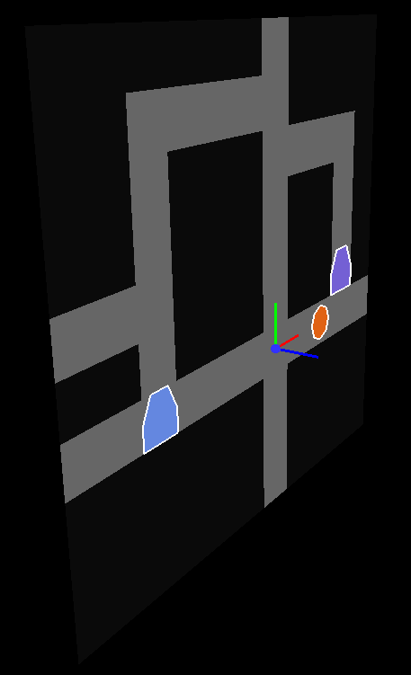

You should further see the correct movements of the pieces in time when using `UP` and `DOWN` keys. 2D Pacman is complete!

### 4. Computation and visualization of motion behavior

This part will be implemented in `pacman.cpp`

Compute the motion for all the vertices of Pac-Man and the ghosts for a time intervall of [0s, 8s]. For a linear motion segment, i.e. a segment where Pac-Man or the ghosts respectively do not change their direction, you can compute the displacement of the vertices given at the beginning of the time interval according to:

$$\begin{pmatrix}
x \cr
y \cr
z \cr
\end{pmatrix} = \begin{pmatrix}
x_0 \cr
y_0 \cr
z_0 \cr
\end{pmatrix} + t * \begin{pmatrix}
speed_x \cr
speed_y \cr
-1 \cr
\end{pmatrix}$$

Now, consider the different motion paths in the maze of the given figure. Subdivide the motions of the different characters into linear motion segments, i.e. only compute the new vertex positions for the locations where a character’s direction of motion changes or the locations given at the end of the considered time interval. Given these vertices, define a triangular mesh whose triangles represent the 3D hull geometry approximating a character’s motion. Hereby, consider the following definition of the faces of the hull geometry exemplary shown for one side of the hull geometry approximating the temporal motion in our 3D space:

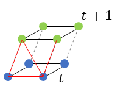

Implement the hull generation in:

```cpp
std::tuple<Hull, Vertices> generateHullGeometry(
    std::span<const glm::vec2> polygon,
    const glm::vec2 initialPosition,
    std::span<const glm::vec2> motionSteps)
```

To see whether the connectivity of the vertices for the mesh generation is correct, you can draw the triangles in the considered 3D space (x,y,t) by implementing:

```cpp
void drawHullMesh(const Vertices& vertices, const Hull& hull, glm::vec4 color)
```

Examples of the generated hulls to compare with your implementation (colors might be different):

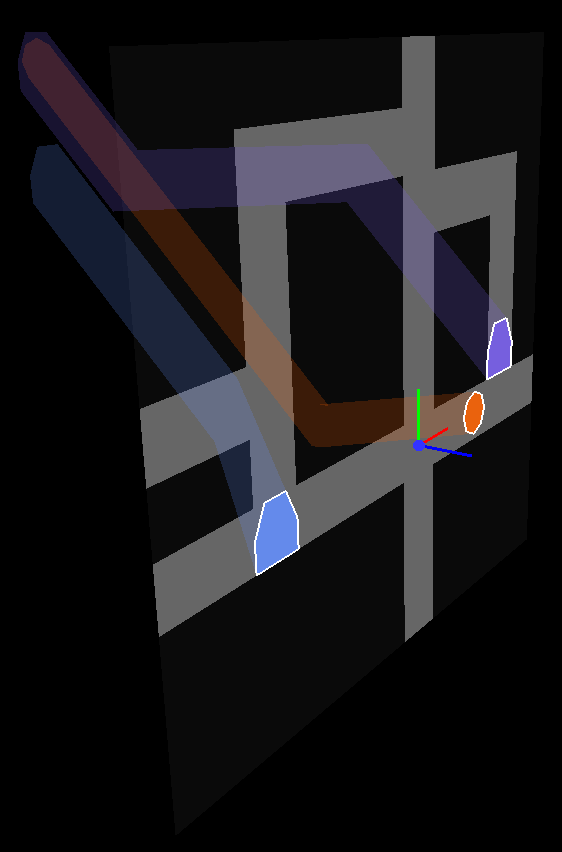

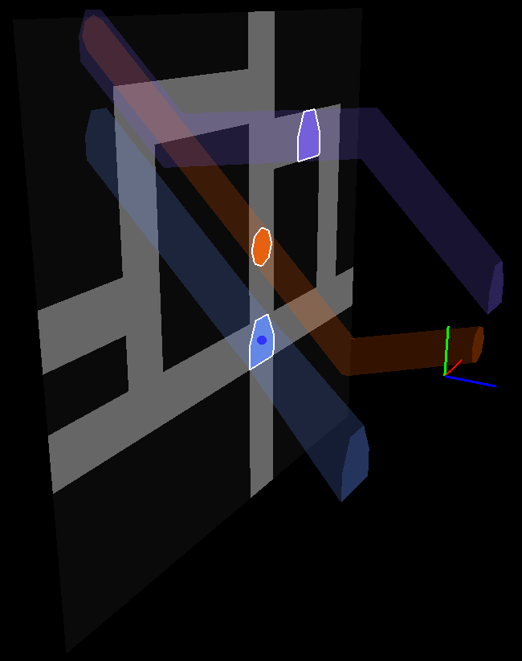

### 5. Intersection tests for collision detection

The following part is to be implemented in `ray_tracing.cpp`.

Based on the spatio-temporal mesh structures we have obtained from the previous steps for Pac-Man and the ghosts, we will now conduct a collision test. For this purpose, you will consider the rays defined based on the sampled shape of Pac-Man and intersect them with the triangles defining the hull geometry of the ghosts’ motion.

#### 5.1 Compute triangle plane

Start by computing the plane defined by three vertices of a triangle.

```cpp
Plane trianglePlane(const glm::vec3& v0, const glm::vec3& v1, const glm::vec3& v2)
```

The `trianglePlane`receives the three vertices of a triangle and defines the plane that contains the triangle, that is, you need to set the plane.normal and plane.D values. The Plane structure is defined as follows:

```cpp
struct Plane {
    float D = 0.0f;
    glm::vec3 normal { 0.0f, 1.0f, 0.0f };
};
```

where D and normal are defined as in the ray tracing lecture.

#### 5.2 Compute the intersection of a ray with a plane

Once you have the plane you should test for ray-plane intersection:

```cpp
bool intersectRayWithPlane(const Plane& plane, Ray& ray)
```

This method `intersectRayWithPlane` receives the plane and the ray, returns false if the ray does not intersect the plane, or true otherwise. If an intersection is found, it should also update the `ray.t` value. In case of an intersection, the next step is to verify if the intersection point is inside the triangle.

#### 5.3 Test whether a point is within a certain triangle

```cpp
bool pointInTriangle(const glm::vec3& v0, const glm::vec3& v1, const glm::vec3& v2, const glm::vec3& n, const glm::vec3& p)
```

This method receives the three vertices of the triangle, the triangle normal, and the point to be verified **p**. It returns true if the point is inside the triangle, false otherwise. Note that a point on the triangle edge is considered as inside the triangle.

#### 5.4 Ray-triangle intersection

Finally, you are ready to join the three previous function:

```cpp
bool intersectRayWithTriangle(const glm::vec3& v0, const glm::vec3& v1, const glm::vec3& v2, Ray& ray)
```

The method `intersectRayWithTriangle` receives the three vertices of a triangle and the ray, and should check the intersection in three steps. First, compute the plane containing the triangle. Second, compute the intersection point of the ray and the plane. If there is an intersection, the third step is to check if the point is inside the triangle.

**Tip** Don’t forget to roll back the `ray.t` value modified in the `intersectRayWithPlane` method if the point is not inside the triangle.

**Obs** The methods will be checked separately by the unit tests, so do not implement everything inside the `intersectRayWithTriangle` method!

Your triangle intersection tests should cover the general case. If you want to debug/inspect your intersection tests with examples other than the hull geometry or the unit test cases, you can implement a test scene and corresponding draw and intersect methods and activate the test scene in the UI.

```cpp
TestScene generateTestScene ()
void drawTestScene (const TestScene &testScene)
bool intersectTestScene (const TestScene &testScene, Ray &ray)
```

By default, we provide a dummy test scene with a single triangle to illustrate the functionality. This part is not required and only supposed to ease your debugging.

#### 6. Collision detection in space-time domain

Now that you have implemented ray-triangle intersection, use it for collision detection and see if/when Pac-Man collides with any of the ghosts for the given scenario. For this purpose, use the rays defined by the motion of Pac-Man’s vertices and intersect them with the triangle mesh representing the hull geometry of both ghosts.

Given the vertices and hulls defining the ghosts, intersect the ray with their triangles to determine if it intersects with the ghosts in spacetime: (This method is still in `ray_tracing.cpp`)

```cpp
bool intersectRayWithGhosts(const std::span<Vertices> vertices, const std::span<Hull> hulls, Ray &ray)
```

If you shoot a ray from the camera using towards one of the ghost hulls it should now intersect.

Finally, we need to generate rays from the pacman vertices at a given time in the motion direction to finish off our collision detection. (This final piece is in `pacman.cpp`)

```cpp
std::vector<Ray> generatePacmanRays (
    std::span<const glm::vec2> polygon,
    const glm::vec2& initialPosition,
    std::span<const glm::vec2> motionSteps,
    const float t)
```

The rays will automatically be colored according to the intersection distance (distinguishing no hit, normal hit, and critically close hit). If you have implemented everything correctly your results will look like this: Note: As soon as the intersection took place, no collision is detected anymore, since we are within the hull. This is by design and not a problem with your implementation (3rd image below).

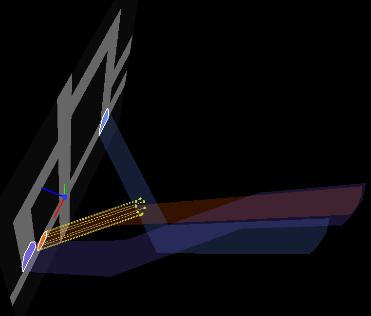

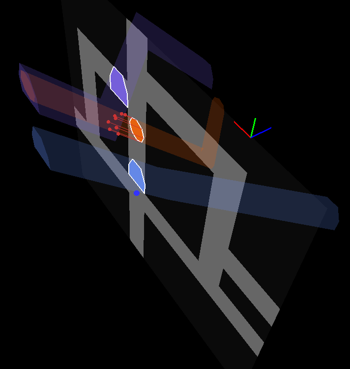

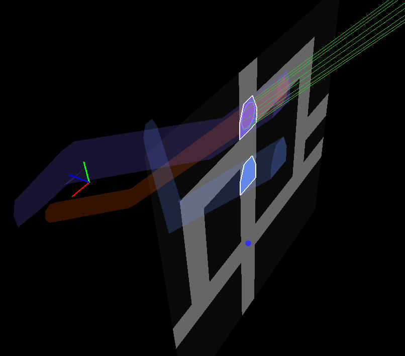